# Analysis of Pilot Data

```r
pilot <- here::here(
  "data",
  "processed_pilot.csv"
) %>%
  read_csv() %>%
  mutate(
    song = gsub(
      "audio/",
      "",
      stimulus_song
    )
  ) %>%
  rename(
    target = target_song
  )
```

In this study we sampled 30 participants, with each participant listening to 42 1 second exceprts. Participants rated each song in terms of the emotion they thought it expressed, it’s valence, and it’s arousal.

# All song consdidered

```r
correct_overall <- pilot %>%
  group_by(target) %>%
  summarise(correct = sum(correct)/n(),
            valence = mean(valence),
            arousal = mean(arousal))
correct_overall %>%
  arrange(target) %>%
  knitr::kable(format = "html") %>%
  kableExtra::kable_styling() %>%
  kableExtra::scroll_box()
```

| target | correct | valence | arousal |
| --- | --- | --- | --- |
| angry | 0.7866667 | 3.380000 | 5.093333 |
| happy | 0.5794872 | 4.533333 | 4.784615 |
| relaxed | 0.4875000 | 4.245833 | 3.954167 |
| sad | 0.4833333 | 3.733333 | 3.620833 |

# Considering Happy, Sad, and Angry taget songs

```r
target_happy <- pilot %>%
  select(target, song, correct, valence, arousal) %>%
  filter(target == "happy") %>%
  group_by(
    song
  ) %>% summarise(
    correct = sum(correct)/n(),
    valence = mean(valence),
    arousal = mean(arousal)
  ) %>%
  arrange(correct)
target_happy
```

| song | correct | valence | arousal |
| --- | --- | --- | --- |
| 12_Skank_Down.mp3 | 0.4333333 | 4.266667 | 5.233333 |
| 4_Make_Light.mp3 | 0.4333333 | 4.400000 | 4.300000 |
| 26_Make_Light.mp3 | 0.5000000 | 4.500000 | 4.733333 |
| 28_Valerie.mp3 | 0.5000000 | 4.433333 | 4.866667 |
| 11_Be_Happy.mp3 | 0.5333333 | 4.366667 | 4.466667 |
| 16_Restless.mp3 | 0.5333333 | 4.200000 | 5.100000 |
| 21_Skank_Down.mp3 | 0.5333333 | 4.300000 | 5.100000 |
| 5_Get_Lucky.mp3 | 0.6000000 | 4.866667 | 4.133333 |
| 24_Restless.mp3 | 0.6333333 | 4.633333 | 4.666667 |
| 5_Valerie.mp3 | 0.6666667 | 5.033333 | 5.300000 |

[output cut: 3 more lines]

Based of this I will retain the following songs as happy songs:

- 21_Skank_Down.mp3
- 16_Restless.mp3
- 5_Get_Lucky.mp3
- 5_Valrie.mp3
- 1_Be_Happy.mp3.
- 26_Make_Light.mp3

I will find the mean correct for these songs to approximate a match with teh sad songs in terms of difficulty

```r
selected_happy <- target_happy %>%
  filter(
    song %in% c("21_Skank_Down.mp3", "26_Make_Light.mp3", "5_Valerie.mp3", "11_Be_Happy.mp3", "16_Restless.mp3", "5_Get_Lucky.mp3")
  )

range(selected_happy$correct)
```

```
## [1] 0.5000000 0.6666667
```

```r
mean(selected_happy$correct)
```

```
## [1] 0.5611111
```

```r
target_sad <- pilot %>%
  select(target, song, correct, valence, arousal) %>%
  filter(target == "sad") %>%
  group_by(
    song
  ) %>% summarise(
    correct = sum(correct)/n(),
    valence = mean(valence),
    arousal = mean(arousal)
  ) %>%
  arrange(correct) %>%
  filter(correct > .25)
target_sad
```

| song | correct | valence | arousal |
| --- | --- | --- | --- |
| 26_It_Only_Hurts_When_I'm_Breathing.mp3 | 0.3333333 | 4.066667 | 4.100000 |
| 3_It_Only_Hurts_When_I'm_Breathing.mp3 | 0.3666667 | 3.866667 | 4.033333 |
| 25_Old_Blacktop.mp3 | 0.4000000 | 3.533333 | 3.266667 |
| 12_Fire_And_Rain_(LP_Version).mp3 | 0.5000000 | 3.966667 | 3.566667 |
| 15_Here_Today.mp3 | 0.5333333 | 3.733333 | 3.300000 |
| 2_Love's_Requiem.mp3 | 0.5333333 | 3.500000 | 3.466667 |
| 8_Fire_And_Rain__(LP_Version).mp3 | 0.5333333 | 4.033333 | 3.733333 |
| 2_Inside.mp3 | 0.5666667 | 3.833333 | 3.633333 |
| 7_Here_Today.mp3 | 0.5666667 | 3.733333 | 3.433333 |
| 3_Old_Blacktop.mp3 | 0.7000000 | 3.566667 | 3.733333 |

[output cut: 3 more lines]

Based of this I will retain the following songs as sad songs:

```r
selected_sad <- target_sad %>%
  filter(
    song %in% c("8_Fire_And_Rain_(LP_Version).mp3", "3_Old_Blacktop.mp3", "15_Here_Today.mp3", "7_Here_Today.mp3", "2_Inside.mp3", "12_Skinny_Love.mp3")
  )

range(selected_sad$correct)
```

```
## [1] 0.5333333 0.7333333
```

```r
mean(selected_sad$correct)
```

```
## [1] 0.62
```

Here the ranges and means are as approximate as possible without duplicating songs.

I also want to have angry target songs

```r
target_angry <- pilot %>%
  select(target, song, correct, valence, arousal) %>%
  filter(target == "angry") %>%
  group_by(
    song
  ) %>% summarise(
    correct = sum(correct)/n(),
    valence = mean(valence),
    arousal = mean(arousal)
  ) %>%
  arrange(correct)
target_angry
```

| song | correct | valence | arousal |
| --- | --- | --- | --- |
| 13_Motown_Junk.mp3 | 0.5333333 | 3.900000 | 5.266667 |
| 2_Incomplete.mp3 | 0.7333333 | 3.766667 | 5.266667 |
| 2_Blood_On_The_Ground.mp3 | 0.7666667 | 3.566667 | 5.033333 |
| 9_Pain_(Live_Version).mp3 | 0.9000000 | 3.233333 | 5.200000 |
| 15_Bunkertor_7_(German_Texture).mp3 | 1.0000000 | 2.433333 | 4.700000 |

Here I will use - 13_Motown_Junk.mp3 - 2_Incomplete.mp3

```r
selected_angry <- target_angry %>%
  filter(
    song %in% c("13_Motown_Junk.mp3", "2_Incomplete.mp3")
  )

range(selected_angry$correct)
```

```
## [1] 0.5333333 0.7333333
```

```r
mean(selected_angry$correct)
```

```
## [1] 0.6333333
```

```r
selected_songs <- pilot %>%
  select(target, song, correct, valence, arousal) %>%
  group_by(song) %>%
  summarise(
    valence = mean(valence),
    arousal = mean(arousal),
    target = target,
    correct = sum(correct)/n()
  ) %>%
  filter(
    song %in% c("25_Old_Blacktop.mp3", "12_Fire_And_Rain_(LP_Version).mp3", "15_Here_Today.mp3", "2_Love's_Requiem.mp3", "2_Inside.mp3", "12_Skank_Down.mp3", "26_Make_Light.mp3", "28_Valerie.mp3", "11_Be_Happy.mp3", "16_Restless.mp3", "13_Motown_Junk.mp3", "2_Incomplete.mp3")
  ) %>%
  distinct() %>%
  arrange(target) %>%
  knitr::kable() %>%
  kableExtra::kable_styling()
kableExtra::save_kable(
  selected_songs,
  here::here(
  "selected_songs_tab.html"
)
)
```

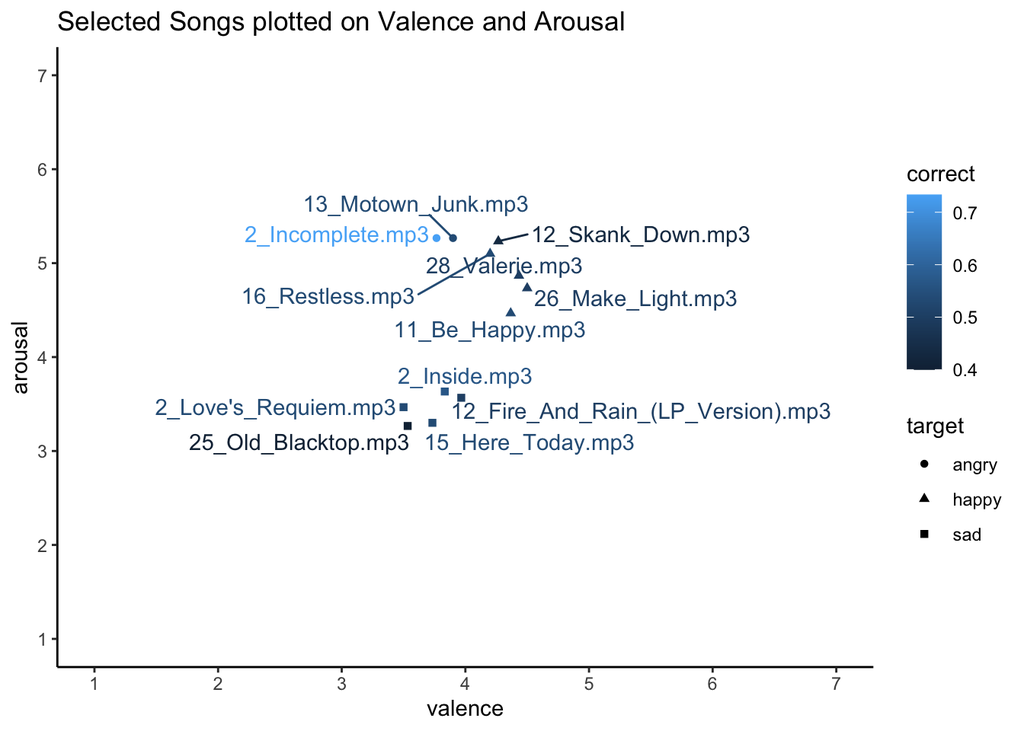

```r
pilot %>%
  select(target, song, correct, valence, arousal) %>%
  group_by(song) %>%
  summarise(
    valence = mean(valence),
    arousal = mean(arousal),
    target = target,
    correct = sum(correct)/n()
  ) %>%
  filter(
    song %in% c("25_Old_Blacktop.mp3", "12_Fire_And_Rain_(LP_Version).mp3", "15_Here_Today.mp3", "2_Love's_Requiem.mp3", "2_Inside.mp3", "12_Skank_Down.mp3", "26_Make_Light.mp3", "28_Valerie.mp3", "11_Be_Happy.mp3", "16_Restless.mp3", "13_Motown_Junk.mp3", "2_Incomplete.mp3")
  ) %>%
  distinct() %>%
  ggplot2::ggplot(
    aes(
      x = valence,
      y = arousal,
      shape = target,
      label = song,
      color = correct
    )
  )+
  geom_point() +
  theme_classic() +
  ggrepel::geom_text_repel() +
  coord_cartesian(xlim = c(1, 7), ylim = c(1, 7)) +
  ggplot2::ggtitle("Selected Songs plotted on Valence and Arousal") +
  scale_x_continuous(breaks = c(1:7)) +
  scale_y_continuous(breaks = c(1:7))
```

```r
ggsave(
  here::here(
    "selected_songs_plt.png"
  )
)
```